# Mcap Developmental pH Timeseries WGCNA

Erin Chille

Last updated 2021/02/17

# BSF Biomineralization Project: RNAseq Expression and Functional Enrichment Analysis

This script is based off of Langfelder P, Horvath S (2008) WGCNA: an R package for weighted correlation network analysis. BMC Bioinformatics 2008, 9:559 ([link to paper](http://www.biomedcentral.com/1471-2105/9/559))

## Set up workspace

Import necessary libraries

```r
library("tidyverse")
library("genefilter")
library("DESeq2")
library("RColorBrewer")
library("WGCNA")
library("flashClust")
library("gridExtra")
library("ComplexHeatmap")
library("goseq")
library("dplyr")
library("clusterProfiler")
library("simplifyEnrichment")
```

## Data input, cleaning, and pre-processing

Import the data files

```r
treatmentinfo <- read.csv("Sample_Info/RNAseq_data.csv", header = TRUE, sep = ",")
head(treatmentinfo)
```

```
##   sample_id       time_point treatment extraction_batch
## 1      X119 Unfertilized_egg       amb                0
## 2      X120 Unfertilized_egg       amb                0
## 3      X121 Unfertilized_egg       amb               12
## 4      X127   Fertilized_egg       amb               10
## 5      X128   Fertilized_egg         l               11
## 6      X129   Fertilized_egg        xl               10
```

```r
gcount <- as.data.frame(read.csv("2-QC-Align-Assemble/Output/gene_count_matrix.csv", row.names="gene_id"), colClasses = double)
head(gcount)
```

```
##                    X1101 X119 X120 X121 X127 X128 X129 X130 X131 X132 X133 X134
## g16981               124    0    0   11    0   22    0    0    0    0    0    0
## g16980                 8    0    0    0    0    0    0    0    0    0    0    0
## g16983                 0    0    0    0    0    0    0    0    0    0    0    0
## adi2mcaRNA10886_R1     0    0    0    0    0    0    0    0    0    0    0    0
## g16985                13    0    0    0    0    0    0    0    0    0    0    0
## g16984                54    0    0    0    0    0    0    0    0    0    0    0
##                    X153 X154 X1548 X155 X156 X157 X158 X159 X160 X162 X1628
## g16981                0    0    47    0    0   22    0   50   53   31   182
## g16980                0    0     0    0    0    0    0    0    0    0     7
## g16983                0    0     0    0    0    0    0    0    0    0     5
## adi2mcaRNA10886_R1    0    0     0    0    0    0    0    0    0    8     0
## g16985                0    0     1    0    0    0    0    0    0    0    13
## g16984                0    0     0    0    0    4    0    0    0    0     0
##                    X163 X164 X165 X166 X167 X168 X169 X179 X180 X181 X182 X183
## g16981               25    0   45   35    0   40   10   15   11    0    0   13
## g16980                0    0    0    0    0    0    0    0    0    0    0    0
## g16983                0    0    0    2    4    4    0    0    0    0    0    0
## adi2mcaRNA10886_R1    0    0    0   15    0    3    0    0    0    0    0    0
## g16985                0    0    0    0    0    0    0    0    0    0    0    0
## g16984                0    0    0    0    0    0    0    0    0    0    0    0
##                    X184 X185 X186 X212 X215 X218 X221 X359 X361 X363 X365 X367
## g16981               26    0    0    0    0   36   11   28   28   33  100   16
## g16980                0    0    0    0    0    4    0    0    0    4    0    4
## g16983                0    0    3    0    0    0    0    0    0    0    0    0
## adi2mcaRNA10886_R1    0    0    0    0    0    0    0    0   14    6    0   14
## g16985                0    0    0    0    4    0    0   16    2    3    0    0
## g16984                0    0    0    1    0    4    3    4   14   19   36    9
##                    X371 X373 X375 X379
## g16981               81   24  180   30
## g16980                0    0    0    3
## g16983                0    0    1    2
## adi2mcaRNA10886_R1    0    0    0    5
## g16985                1    4   10    4
## g16984               21   19   15   11
```

```r
dim(gcount)
```

```
## [1] 63227    51
```

#### Quality-filter gene counts

Pre-filtering our dataset to reduce the memory size dataframe, increase the speed of the transformation and testing functions, and improve quality of statistical analysis by removing low-coverage counts. Removed counts could represent outliers in the data and removing these improves sensitivity of statistical tests. Here we will filter out the genes that are only present in fewer than 2 of the 41 samples.

```r
#keep only life stages with three treatments: Fertilized_egg, Cleavage, Prawn_chip, Early_gastrula, Planula
dev <- c("Fertilized_egg", "Cleavage", "Prawn_chip", "Early_gastrula", "Planula")
treatmentinfo_dev <- filter(treatmentinfo, time_point %in% dev)
dim(treatmentinfo_dev) #rows 41
```

```
## [1] 41  4
```

```r
# delete sample columns corresponding to low and extreme low samples by mapping Null value to them
gcount_dev <- gcount[treatmentinfo_dev$sample_id]
dim(gcount_dev) #columns 41
```

```
## [1] 63227    41
```

```r
#create filter for the counts data
#gfiltdev <- rowSums(count(gcount_dev)) > 0
#set filter values for PoverA, P=4.88% percent of the samples have counts over A=10. This means that only 2 out of 41 (0.04878049) samples need to have counts over 10 because our smallest sample size for a treatment is 2. By setting 2/41 as the P, this means if a particular gene is expressed only in 1 of these smallest life stages, it will be included in the analysis.
filt <- filterfun(pOverA(0.04878049,10))

#create filter for the counts data
gfiltdev <- genefilter(gcount_dev, filt)

#identify genes to keep by count filter
gkeepdev <- gcount_dev[gfiltdev,]


#identify genes to keep by count filter
gkeepdev <- gcount_dev[gfiltdev,]

#identify gene lists
gn.keepdev <- rownames(gkeepdev)

#gene count data filtered in PoverA, P percent of the samples have counts over A
gcount_filt_dev <- as.data.frame(gcount_dev[which(rownames(gcount_dev) %in% gn.keepdev),])

#How many rows do we have before and after filtering?
nrow(gcount_dev) #Before
```

```
## [1] 63227
```

```r
nrow(gcount_filt_dev) #After
```

```
## [1] 30271
```

### Quality-check of datasets

In order for the DESeq2 algorithms to work, the SampleIDs on the treatmentinfo file and count matrices have to match exactly and in the same order. The following R clump will check to make sure that these match.

```r
#Checking that all row and column names match. Should return "TRUE"
all(treatmentinfo_dev$sample_id %in% colnames(gcount_filt_dev))
```

```
## [1] TRUE
```

```r
all(treatmentinfo_dev$sample_id == colnames(gcount_filt_dev))
```

```
## [1] TRUE
```

### Read normalization

We are now going normalize our read counts using VST-normalization in DESeq2

#### Construct the DESeq2 dataset

Merge the treatment and time_point columns into a new column , group. Set group as a factor.

```r
treatmentinfo_dev$time_point <- factor(treatmentinfo_dev$time_point, levels = c("Fertilized_egg", "Cleavage", "Prawn_chip", "Early_gastrula", "Planula"))
treatmentinfo_dev$treatment <- factor(treatmentinfo_dev$treatment, levels = c("amb", "l", "xl"))
```

Create a DESeqDataSet design from gene count matrix and labels. Here we set the design to look at time_point to test for any differences in gene expression across timepoints.

```r
#Set DESeq2 design
gdds_dev <- DESeqDataSetFromMatrix(countData = gcount_filt_dev,
                              colData = treatmentinfo_dev,
                              design = ~time_point + treatment + time_point:treatment)
```

#### Log-transform the count data

First we are going to log-transform the data using a variance stabilizing transforamtion (VST). This is only for visualization purposes. Essentially, this is roughly similar to putting the data on the log2 scale. It will deal with the sampling variability of low counts by calculating within-group variability (if blind=FALSE). Importantly, it does not use the design to remove variation in the data, and so can be used to examine if there may be any variability do to technical factors such as extraction batch effects.

To do this we first need to calculate the size factors of our samples. This is a rough estimate of how many reads each sample contains compared to the others. In order to use VST (the faster log2 transforming process) to log-transform our data, the size factors need to be less than 4. Otherwise, there could be artefacts in our results.

```r
SF.gdds_dev <- estimateSizeFactors(gdds_dev) #estimate size factors to determine if we can use vst  to transform our data. Size factors should be less than for to use vst
print(sizeFactors(SF.gdds_dev)) #View size factors
```

```
##      X127      X128      X129      X130      X131      X132      X133      X134
## 0.5702756 0.7074022 0.5917577 0.8043547 0.3713205 0.5696354 0.7781648 0.4170494
##      X153      X154      X155      X156      X157      X158      X159      X160
## 1.0264010 1.9108755 1.3157932 1.4161517 0.7496309 0.6565842 0.7967886 1.3344453
##      X162      X163      X164      X165      X166      X167      X168      X169
## 1.4548882 1.6916817 1.7424586 2.0873968 1.9074420 1.7051110 1.5369072 1.2681979
##      X179      X180      X181      X182      X183      X184      X185      X186
## 0.9671276 0.7910800 1.0075282 1.7434195 1.1145099 0.8920753 0.8575312 0.9188194
##      X359      X361      X363      X365      X367      X371      X373      X375
## 1.3201012 1.2469608 1.4461240 1.1491640 1.1205240 1.2015356 0.9114857 0.9980661
##      X379
## 1.1894747
```

Our size factors are all less than 4, so we can use VST!

```r
gvst_dev <- vst(gdds_dev, blind=TRUE) #apply a variance stabilizing transforamtion to minimize effects of small counts and normalize wrt library size
head(assay(gvst_dev), 3) #view transformed gene count data
```

```
##                        X127     X128     X129     X130     X131     X132
## g16981             5.135942 6.447147 5.135942 5.135942 5.135942 5.135942
## adi2mcaRNA10886_R1 5.135942 5.135942 5.135942 5.135942 5.135942 5.135942
## g16984             5.135942 5.135942 5.135942 5.135942 5.135942 5.135942
##                        X133     X134     X153     X154     X155     X156
## g16981             5.135942 5.135942 5.135942 5.135942 5.135942 5.135942
## adi2mcaRNA10886_R1 5.135942 5.135942 5.135942 5.135942 5.135942 5.135942
## g16984             5.135942 5.135942 5.135942 5.135942 5.135942 5.135942
##                        X157     X158     X159     X160     X162     X163
## g16981             6.411972 5.135942 6.942821 6.604948 6.232424 6.055588
## adi2mcaRNA10886_R1 5.135942 5.135942 5.135942 5.135942 5.702805 5.135942
## g16984             5.694458 5.135942 5.135942 5.135942 5.135942 5.135942
##                        X164     X165     X166     X167     X168     X169
## g16981             5.135942 6.238555 6.156706 5.135942 6.341745 5.812909
## adi2mcaRNA10886_R1 5.135942 5.135942 5.812012 5.135942 5.475079 5.135942
## g16984             5.135942 5.135942 5.135942 5.135942 5.135942 5.135942
##                        X179     X180     X181     X182     X183     X184
## g16981             6.077321 6.028866 5.135942 5.135942 5.955802 6.407832
## adi2mcaRNA10886_R1 5.135942 5.135942 5.135942 5.135942 5.135942 5.135942
## g16984             5.135942 5.135942 5.135942 5.135942 5.135942 5.135942
##                        X185     X186     X359     X361     X363     X365
## g16981             5.135942 5.135942 6.230039 6.260178 6.268840 7.219639
## adi2mcaRNA10886_R1 5.135942 5.135942 5.135942 5.940690 5.629114 5.135942
## g16984             5.135942 5.135942 5.557947 5.940690 6.004645 6.451627
##                        X367     X371     X373     X375     X379
## g16981             6.040421 7.000957 6.348389 7.940398 6.323950
## adi2mcaRNA10886_R1 5.983680 5.135942 5.135942 5.135942 5.632312
## g16984             5.819066 6.133111 6.220998 6.063105 5.867938
```

##### Plot a heatmap of sample-to-sample distances

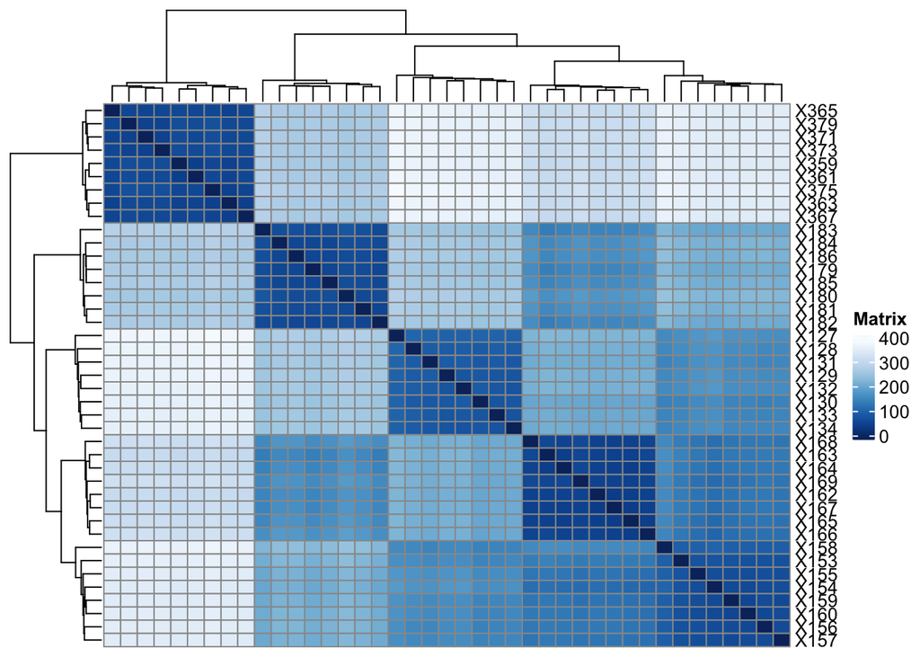

```r
gsampleDists_dev <- dist(t(assay(gvst_dev))) #calculate distance matix
gsampleDistMatrix_dev <- as.matrix(gsampleDists_dev) #distance matrix
rownames(gsampleDistMatrix_dev) <- colnames(gvst_dev) #assign row names
colnames(gsampleDistMatrix_dev) <- NULL #assign col names
colors <- colorRampPalette( rev(brewer.pal(9, "Blues")) )(255) #assign colors
pheatmap(gsampleDistMatrix_dev, #plot matrix
         clustering_distance_rows=gsampleDists_dev, #cluster rows
         clustering_distance_cols=gsampleDists_dev, #cluster columns
         col=colors) #set colors
```

##### Principal component plot of samples

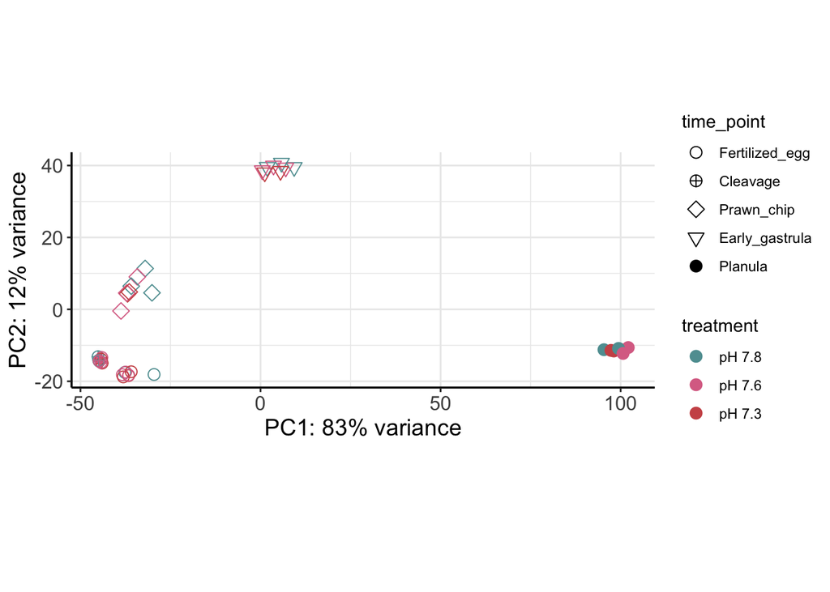

```r
gPCAdata_dev <- plotPCA(gvst_dev, intgroup = c("time_point", "treatment"), returnData=TRUE)
percentVar_dev <- round(100*attr(gPCAdata_dev, "percentVar")) #plot PCA of samples with all data

allgenesfilt_PCA <- ggplot(gPCAdata_dev, aes(PC1, PC2, shape=time_point, color=treatment)) +
  geom_point(size=3) +
  xlab(paste0("PC1: ",percentVar_dev[1],"% variance")) +
  ylab(paste0("PC2: ",percentVar_dev[2],"% variance")) +
  scale_shape_manual(values = c("Fertilized_egg"=1, "Cleavage"=10, "Prawn_chip"=5, "Early_gastrula"=6, "Planula"=19)) +
  scale_color_manual(labels = c("pH 7.8", "pH 7.6","pH 7.3"), values = c("amb"="cadetblue", "l"="palevioletred", "xl"="indianred3")) +
  coord_fixed() +
  theme_bw() + #Set background color
  theme(panel.border = element_blank(), # Set border
                     #panel.grid.major = element_blank(), #Set major gridlines
                     #panel.grid.minor = element_blank(), #Set minor gridlines
                     axis.line = element_line(colour = "black", size = 0.6), #Set axes color
        plot.background=element_blank(), #Set the plot background
        axis.title = element_text(size = 14), #Axis title size
        axis.text = element_text(size = 12)) #Axis text size
allgenesfilt_PCA
```

```r
# ggsave(file = "3-WGCNA/Output/Fig3-allgenesfilt-PCA.png", allgenesfilt_PCA, width = 7.5, height = 11/2, units = "in")
```

### Compile WGCNA Dataset

Transpose the filtered gene count matrix so that the gene IDs are rows and the sample IDs are columns.

```r
datExpr <- as.data.frame(t(assay(gvst_dev))) #transpose to output to a new data frame with the column names as row names. And make all data numeric
```

Check for genes and samples with too many missing values with goodSamplesGenes. There shouldn’t be any because we performed pre-filtering

```r
gsg = goodSamplesGenes(datExpr, verbose = 3)
```

```
##  Flagging genes and samples with too many missing values...
##   ..step 1
```

```r
gsg$allOK #Should return TRUE if not, the R chunk below will take care of flagged data
```

```
## [1] TRUE
```

Remove flagged samples if the allOK is FALSE

```r
ncol(datExpr) #number genes before
```

```
## [1] 30271
```

```r
if (!gsg$allOK) #If the allOK is FALSE...
{
# Optionally, print the gene and sample names that are flagged:
if (sum(!gsg$goodGenes)>0)
printFlush(paste("Removing genes:", paste(names(datExpr)[!gsg$goodGenes], collapse = ", ")));
if (sum(!gsg$goodSamples)>0)
printFlush(paste("Removing samples:", paste(rownames(datExpr)[!gsg$goodSamples], collapse = ", ")));
# Remove the offending genes and samples from the data:
datExpr = datExpr[gsg$goodSamples, gsg$goodGenes]
}
ncol(datExpr) #number genes after
```

```
## [1] 30271
```

### Cluster the samples to look for obvious outliers

Look for outliers by examining

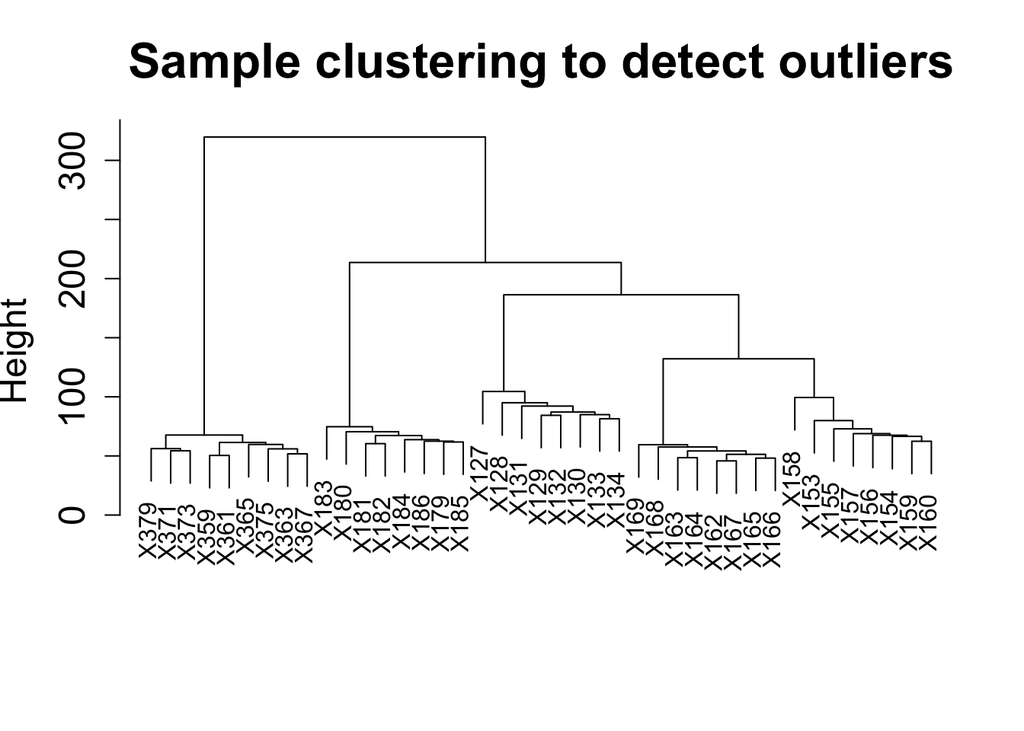

```r
sampleTree = hclust(dist(datExpr), method = "average");
# Plot the sample tree: Open a graphic output window of size 12 by 9 inches
# The user should change the dimensions if the window is too large or too small.
plot(sampleTree, main = "Sample clustering to detect outliers", sub="", xlab="", cex.lab = 1.5, cex.axis = 1.5, cex.main = 2)
```

There don’t look to be any outliers, so we will move on with business as usual.

## Network construction and consensus module detection

### Choosing a soft-thresholding power: Analysis of network topology β

The soft thresholding power (β) is the number to which the co-expression similarity is raised to calculate adjacency. The function pickSoftThreshold performs a network topology analysis. The user chooses a set of candidate powers, however the default parameters are suitable values.

```r
# Choose a set of soft-thresholding powers
powers <- c(seq(from = 1, to=19, by=2), c(21:30)) #Create a string of numbers from 1 through 10, and even numbers from 10 through 20

# Call the network topology analysis function
sft <-pickSoftThreshold(datExpr, powerVector = powers, verbose = 5)
```

```
## pickSoftThreshold: will use block size 1477.
##  pickSoftThreshold: calculating connectivity for given powers...
##    ..working on genes 1 through 1477 of 30271
##    ..working on genes 1478 through 2954 of 30271
##    ..working on genes 2955 through 4431 of 30271
##    ..working on genes 4432 through 5908 of 30271
##    ..working on genes 5909 through 7385 of 30271
##    ..working on genes 7386 through 8862 of 30271
##    ..working on genes 8863 through 10339 of 30271
##    ..working on genes 10340 through 11816 of 30271
##    ..working on genes 11817 through 13293 of 30271
##    ..working on genes 13294 through 14770 of 30271
##    ..working on genes 14771 through 16247 of 30271
##    ..working on genes 16248 through 17724 of 30271
##    ..working on genes 17725 through 19201 of 30271
##    ..working on genes 19202 through 20678 of 30271
##    ..working on genes 20679 through 22155 of 30271
##    ..working on genes 22156 through 23632 of 30271
##    ..working on genes 23633 through 25109 of 30271
##    ..working on genes 25110 through 26586 of 30271
##    ..working on genes 26587 through 28063 of 30271
##    ..working on genes 28064 through 29540 of 30271
##    ..working on genes 29541 through 30271 of 30271
##    Power SFT.R.sq   slope truncated.R.sq mean.k. median.k. max.k.
## 1      1   0.9580  2.0900          0.967   14500   15700.0  19800
## 2      3   0.0288  0.0612         -0.114    6470    6600.0  12600
## 3      5   0.4810 -0.3870          0.405    3810    3410.0   9320
## 4      7   0.7180 -0.5870          0.674    2540    1960.0   7380
## 5      9   0.8010 -0.7270          0.772    1820    1200.0   6140
## 6     11   0.8600 -0.8140          0.839    1370     776.0   5250
## 7     13   0.9210 -0.8620          0.908    1070     523.0   4570
## 8     15   0.9600 -0.8940          0.952     854     362.0   4020
## 9     17   0.9780 -0.9210          0.975     698     261.0   3610
## 10    19   0.9890 -0.9470          0.986     581     193.0   3270
## 11    21   0.9950 -0.9680          0.993     491     145.0   2980
## 12    22   0.9960 -0.9750          0.995     453     126.0   2860
## 13    23   0.9970 -0.9830          0.996     419     110.0   2740
## 14    24   0.9970 -0.9920          0.996     389      96.7   2650
## 15    25   0.9960 -1.0000          0.995     363      84.4   2560
## 16    26   0.9950 -1.0100          0.994     338      74.4   2480
## 17    27   0.9930 -1.0200          0.992     316      65.5   2400
## 18    28   0.9940 -1.0300          0.992     296      57.9   2330
## 19    29   0.9930 -1.0400          0.992     278      51.5   2270
## 20    30   0.9930 -1.0500          0.992     262      45.8   2200
```

Plot the results.

```r
sizeGrWindow(9, 5)
par(mfrow = c(1,2));
cex1 = 0.9;
# # Scale-free topology fit index as a function of the soft-thresholding power
plot(sft$fitIndices[,1], -sign(sft$fitIndices[,3])*sft$fitIndices[,2],
     xlab="Soft Threshold (power)",ylab="Scale Free Topology Model Fit,signed R^2",type="n",
    main = paste("Scale independence"));
text(sft$fitIndices[,1], -sign(sft$fitIndices[,3])*sft$fitIndices[,2],
    labels=powers,cex=cex1,col="red");
# # this line corresponds to using an R^2 cut-off
abline(h=0.9,col="red")
# # Mean connectivity as a function of the soft-thresholding power
plot(sft$fitIndices[,1], sft$fitIndices[,5],
    xlab="Soft Threshold (power)",ylab="Mean Connectivity", type="n",
    main = paste("Mean connectivity"))
text(sft$fitIndices[,1], sft$fitIndices[,5], labels=powers, cex=cex1,col="red")
```

[output not shown]

## Step-by-step network construction and module detection:

### Co-expression adjacency and topological overlap matrix similarity

The next few steps will be executed in supercomputer, Bluewaves, as our dataset is too large for most standard laptops to handle.

Save Rdata necessary for analysis in Bluewaves

```r
save(datExpr, file = "3-WGCNA/Input/datExpr.RData")
```

**To be executed on the Bluewaves server**  
Co-expression similarity and adjacency, using the soft thresholding power 13 and translate the adjacency into topological overlap matrix to calculate the corresponding dissimilarity. I will use a **signed network** because we have a relatively high softPower, according to (>12): https://peterlangfelder.com/2018/11/25/__trashed/

```r
# #Set up workspace
# getwd() #Display the current working directory
# #If necessary, change the path below to the directory where the data files are stored. "." means current directory. On Windows use a forward slash / instead of the usual \.
# workingDir = ".";
# setwd(WGCNA_dev);
# library(WGCNA) #Load the WGCNA package
# options(stringsAsFactors = FALSE) #The following setting is important, do not omit.
# enableWGCNAThreads() #Allow multi-threading within WGCNA.
#
# #Load the data saved in the first part
# adjTOM <- load(file="datExpr.RData")
# adjTOM
#
# #Run analysis
# softPower=13 #Set softPower to 13
# adjacency=adjacency(datExpr, power=softPower,type="signed") #Calculate adjacency
# TOM= TOMsimilarity(adjacency,TOMType = "signed") #Translate adjacency into topological overlap matrix
# dissTOM= 1-TOM #Calculate dissimilarity in TOM
# save(adjacency, TOM, dissTOM, file = "../adjTOM.RData") #Save to bluewaves dir
# save(dissTOM, file = "../dissTOM.RData") #Save to bluewaves dir
```

### Clustering using TOM

Form distance matrix

```r
# geneTree= flashClust(as.dist(dissTOM), method="average")
```

We will now plot a dendrogram of genes. Each leaf corresponds to a gene, branches grouping together densely are interconnected, highly co-expressed genes.

```r
# pdf(file="dissTOMClustering.pdf", width=20, height=20)
# plot(geneTree, xlab="", sub="", main= "Gene Clustering on TOM-based dissimilarity", labels= FALSE,hang=0.04)
# dev.off()
```

### Module identification using dynamicTreeCut

Module identification is essentially cutting the branches off the tree in the dendrogram above. We like large modules, so we set the **minimum module size** relatively high, so we will set the minimum size at 30. I chose 30 as it is the default value chosen by most studies using WGCNA.

```r
# minModuleSize = 30
# dynamicMods = cutreeDynamic(dendro = geneTree, distM = dissTOM,
# deepSplit = 2, pamRespectsDendro = FALSE,
# minClusterSize = minModuleSize)
# table(dynamicMods) #list modules and respective sizes
# save(dynamicMods, geneTree, file = "dyMod_geneTree.RData") #Save to bluewaves dir and scp to 3-WGCNA/Input dir
```

Module 0 is reserved for unassigned genes. The are other modules will be listed largest to smallest.

**Now we can continue using Rstudio**

Load modules calculated from the adjacency matrix

```r
dyMod_geneTree <- load(file = "3-WGCNA/Input/dyMod_geneTree.RData")
dyMod_geneTree
```

```
## [1] "dynamicMods" "geneTree"
```

```r
geneTree
```

```
##
## Call:
## hclust(d = as.dist(dissTOM), method = "average")
##
## Cluster method   : average
## Number of objects: 30271
```

Plot the module assignment under the gene dendrogram

```r
dynamicColors = labels2colors(dynamicMods) # Convert numeric labels into colors
table(dynamicColors)
```

```
## dynamicColors
##          black           blue          brown           cyan      darkgreen
##            839           3605           2250            470            205
##       darkgrey    darkmagenta darkolivegreen     darkorange        darkred
##            150             72             80            132            214
##  darkturquoise          green    greenyellow         grey60      lightcyan
##            152            957            632            272            295
##     lightgreen    lightyellow        magenta   midnightblue         orange
##            250            249            716            402            141
##  paleturquoise           pink         purple            red      royalblue
##             95            827            651            852            249
##    saddlebrown         salmon        sienna3        skyblue      steelblue
##            111            483             67            118            107
##            tan      turquoise         violet          white         yellow
##            505          12708             84            126           1155
##    yellowgreen
##             50
```

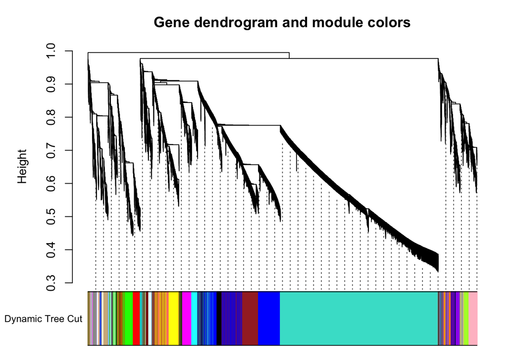

```r
plotDendroAndColors(geneTree, dynamicColors, "Dynamic Tree Cut", dendroLabels = FALSE, hang = 0.03, addGuide = TRUE, guideHang = 0.05, main = "Gene dendrogram and module colors")
```

### Merge modules whose expression profiles are very similar or choose not to merge

Plot module similarity based on eigengene value

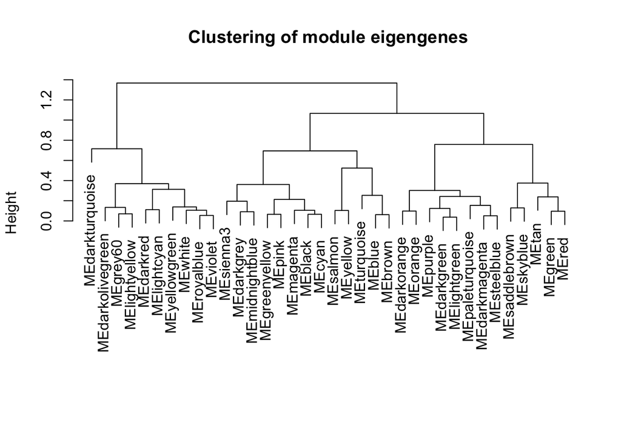

```r
#Calculate eigengenes
MEList = moduleEigengenes(datExpr, colors = dynamicColors, softPower = 13)
MEs = MEList$eigengenes

#Calculate dissimilarity of module eigengenes
MEDiss = 1-cor(MEs)

#Cluster again and plot the results
METree = flashClust(as.dist(MEDiss), method = "average")

plot(METree, main = "Clustering of module eigengenes", xlab = "", sub = "")
```

We only have 36 modules from our initial clustering, and we want to maximize differences because we expect the most variation to be due to developmental stage, so we will not merge.

## Relating modules to developmental stage

### Quantifying module–trait associations

Prepare trait data. Data has to be numeric, so I will substitute time_points and type for numeric values

```r
treatmentinfo_dev$num <- c("1")
treatmentinfo_dev$group <- paste(sep=".", treatmentinfo_dev$time_point, treatmentinfo_dev$treatment)
allTraits <- as.data.frame(pivot_wider(treatmentinfo_dev, names_from = group, values_from = num, id_cols = sample_id))
allTraits[is.na(allTraits)] <- c("0")
rownames(allTraits) <- allTraits$sample_id
datTraits <- allTraits[,c(-1)]
datTraits
```

```
##      Fertilized_egg.amb Fertilized_egg.l Fertilized_egg.xl Cleavage.amb
## X127                  1                0                 0            0
## X128                  0                1                 0            0
## X129                  0                0                 1            0
## X130                  0                0                 1            0
## X131                  0                1                 0            0
## X132                  1                0                 0            0
## X133                  0                1                 0            0
## X134                  0                0                 1            0
## X153                  0                0                 0            1
## X154                  0                0                 0            1
## X155                  0                0                 0            0
## X156                  0                0                 0            0
## X157                  0                0                 0            0
## X158                  0                0                 0            0
## X159                  0                0                 0            1
## X160                  0                0                 0            0
## X162                  0                0                 0            0
## X163                  0                0                 0            0
## X164                  0                0                 0            0
## X165                  0                0                 0            0
## X166                  0                0                 0            0
## X167                  0                0                 0            0
## X168                  0                0                 0            0
## X169                  0                0                 0            0
## X179                  0                0                 0            0
## X180                  0                0                 0            0
## X181                  0                0                 0            0
## X182                  0                0                 0            0
## X183                  0                0                 0            0
## X184                  0                0                 0            0
## X185                  0                0                 0            0
## X186                  0                0                 0            0
## X359                  0                0                 0            0
## X361                  0                0                 0            0
## X363                  0                0                 0            0
## X365                  0                0                 0            0
## X367                  0                0                 0            0
## X371                  0                0                 0            0
## X373                  0                0                 0            0
```

[output cut: 113 more lines]

```
## X181          0         0
## X182          0         0
## X183          0         0
## X184          0         0
## X185          0         0
## X186          0         0
## X359          0         0
## X361          0         0
## X363          1         0
## X365          1         0
## X367          1         0
## X371          0         1
## X373          0         1
## X375          0         0
## X379          0         1
```

Define numbers of genes and samples

```r
nGenes = ncol(datExpr)
nSamples = nrow(datExpr)
```

Correlations of traits with eigengenes

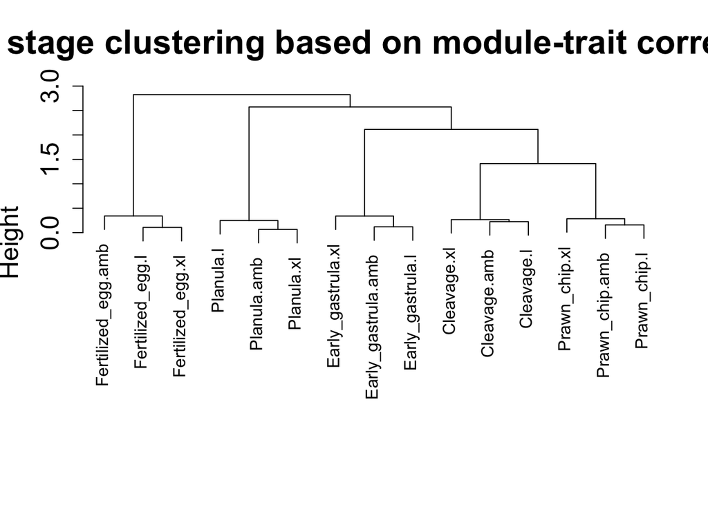

```r
moduleTraitCor = cor(MEs, datTraits, use = "p");
moduleTraitPvalue = corPvalueStudent(moduleTraitCor, nSamples);
Colors=sub("ME","",names(MEs))

moduleTraitTree = hclust(dist(t(moduleTraitCor)), method = "average");
plot(moduleTraitTree, main = "Life stage clustering based on module-trait correlation", sub="", xlab="", cex.lab = 1.5, cex.axis = 1.5, cex.main = 2)
```

Correlations of genes with eigengenes

```r
moduleGeneCor=cor(MEs,datExpr)
moduleGenePvalue = corPvalueStudent(moduleGeneCor, nSamples);
```

### Plot module-trait associations

Represent module trait correlations as a heatmap

```r
textMatrix = paste(signif(moduleTraitCor, 2), "\n(",signif(moduleTraitPvalue, 1), ")", sep = "")
dim(textMatrix) = dim(moduleTraitCor)
head(textMatrix)
```

```
##      [,1]             [,2]             [,3]             [,4]
## [1,] "-0.39\n(0.01)"  "-0.43\n(0.005)" "-0.43\n(0.006)" "-0.17\n(0.3)"
## [2,] "-0.22\n(0.2)"   "-0.26\n(0.09)"  "-0.26\n(0.1)"   "-0.27\n(0.08)"
## [3,] "-0.23\n(0.2)"   "-0.28\n(0.08)"  "-0.27\n(0.08)"  "-0.28\n(0.07)"
## [4,] "-0.47\n(0.002)" "-0.53\n(4e-04)" "-0.51\n(6e-04)" "0.019\n(0.9)"
## [5,] "-0.15\n(0.4)"   "-0.15\n(0.3)"   "-0.16\n(0.3)"   "0.24\n(0.1)"
## [6,] "-0.43\n(0.005)" "-0.47\n(0.002)" "-0.48\n(0.002)" "0.26\n(0.1)"
##      [,5]            [,6]            [,7]            [,8]
## [1,] "-0.22\n(0.2)"  "-0.15\n(0.3)"  "0.19\n(0.2)"   "0.18\n(0.3)"
## [2,] "-0.28\n(0.07)" "-0.22\n(0.2)"  "-0.12\n(0.5)"  "-0.15\n(0.4)"
## [3,] "-0.29\n(0.07)" "-0.22\n(0.2)"  "-0.095\n(0.6)" "-0.15\n(0.4)"
## [4,] "-0.016\n(0.9)" "-0.016\n(0.9)" "0.19\n(0.2)"   "0.19\n(0.2)"
## [5,] "0.21\n(0.2)"   "0.19\n(0.2)"   "0.3\n(0.06)"   "0.29\n(0.07)"
## [6,] "0.22\n(0.2)"   "0.18\n(0.3)"   "0.3\n(0.06)"   "0.31\n(0.05)"
##      [,9]           [,10]          [,11]           [,12]
## [1,] "0.15\n(0.3)"  "0.078\n(0.6)" "0.066\n(0.7)"  "0.074\n(0.6)"
## [2,] "-0.12\n(0.5)" "0.22\n(0.2)"  "0.18\n(0.3)"   "0.17\n(0.3)"
## [3,] "-0.12\n(0.5)" "0.38\n(0.01)" "0.35\n(0.02)"  "0.31\n(0.05)"
## [4,] "0.15\n(0.3)"  "0.06\n(0.7)"  "0.067\n(0.7)"  "0.053\n(0.7)"
## [5,] "0.24\n(0.1)"  "0.13\n(0.4)"  "0.14\n(0.4)"   "0.13\n(0.4)"
## [6,] "0.26\n(0.1)"  "-0.11\n(0.5)" "-0.087\n(0.6)" "-0.062\n(0.7)"
##      [,13]            [,14]            [,15]
## [1,] "0.34\n(0.03)"   "0.34\n(0.03)"   "0.32\n(0.04)"
## [2,] "0.43\n(0.006)"  "0.42\n(0.006)"  "0.41\n(0.008)"
## [3,] "0.29\n(0.07)"   "0.29\n(0.07)"   "0.27\n(0.08)"
## [4,] "0.27\n(0.09)"   "0.27\n(0.09)"   "0.24\n(0.1)"
## [5,] "-0.44\n(0.004)" "-0.44\n(0.004)" "-0.44\n(0.004)"
## [6,] "0.057\n(0.7)"   "0.045\n(0.8)"   "-0.0033\n(1)"
```

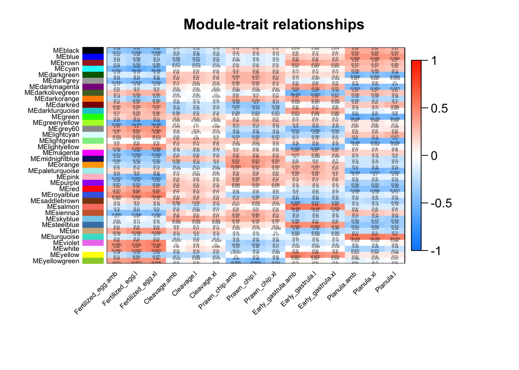

```r
labeledHeatmap(Matrix = moduleTraitCor, xLabels = names(datTraits),  yLabels = names(MEs), ySymbols = names(MEs), cex.lab.y= 0.55, cex.lab.x= 0.55, colors = blueWhiteRed(50), textMatrix = textMatrix, setStdMargins = TRUE, cex.text = 0.25, textAdj = , zlim = c(-1,1), main = paste("Module-trait relationships"))
```

Plot with complexHeatmap

```r
#bold sig p-values
#dendrogram with WGCNA MEtree cut-off
#colored y-axis

#Create list of pvalues for eigengene correlation with specific life stages
heatmappval <- signif(moduleTraitPvalue, 1)

#Make list of heatmap row colors
htmap.colors <- names(MEs)
htmap.colors <- gsub("ME", "", htmap.colors)

pdf(file = "3-WGCNA/Output/Module-trait-relationship-heatmap.pdf", height = 11.5, width = 8)
ht=Heatmap(moduleTraitCor, name = "Eigengene", column_title = "Module-Trait Eigengene Correlation",
        col = blueWhiteRed(50),
        row_names_side = "left", row_dend_side = "left",
        width = unit(5, "in"), height = unit(8.5, "in"),
        column_order = 1:15, column_dend_reorder = TRUE, cluster_columns = hclust(dist(t(moduleTraitCor)), method = "average"), column_dend_height = unit(0.5, "in"),
        cluster_rows = METree, row_gap = unit(2.5, "mm"), border = TRUE,
        cell_fun = function(j, i, x, y, w, h, col) {
        if(heatmappval[i, j] <= 0.05) {
            grid.text(sprintf("%s", heatmappval[i, j]), x, y, gp = gpar(fontsize = 8, fontface = "bold"))
        }
        else {
            grid.text(sprintf("%s", heatmappval[i, j]), x, y, gp = gpar(fontsize = 8, fontface = "plain"))
        }},
        column_names_gp =  gpar(fontsize = 10),
row_names_gp = gpar(fontsize = 10, alpha = 0.75, border = TRUE, fill = htmap.colors))
draw(ht)
dev.off()
```

### Gene relationship to trait and important modules: Gene Significance and Module Membership

We quantify associations of individual genes with life stage by defining Gene Significance GS as the absolute value of the correlation between the gene and the time_point. For each module, we also define a quantitative measure of module membership MM as the correlation of the module eigengene and the gene expression profile.

Define variable weight containing the weight column of datTrait

```r
time_point <- as.data.frame(as.numeric(as.factor(paste(sep=".", treatmentinfo_dev$time_point, treatmentinfo_dev$treatment))))
names(time_point) = "timepoint"
dim(time_point)
```

```
## [1] 41  1
```

Colors of the modules

```r
modNames = substring(names(MEs), 3)

geneModuleMembership = as.data.frame(cor(datExpr, MEs, use = "p"));
MMPvalue = as.data.frame(corPvalueStudent(as.matrix(geneModuleMembership), nSamples));

names(geneModuleMembership) = paste("MM", modNames, sep="");
names(MMPvalue) = paste("p.MM", modNames, sep="");

geneTraitSignificance = as.data.frame(cor(datExpr, time_point, use = "p"));
GSPvalue = as.data.frame(corPvalueStudent(as.matrix(geneTraitSignificance), nSamples));

names(geneTraitSignificance) = paste("GS.", names(time_point), sep="");
names(GSPvalue) = paste("p.GS.", names(time_point), sep="");
```

### Summary output of network analysis results

#### Make a dataframe that connects traits, genes, and gene annotation

Import annotation file.

```r
Mcap.annot <- read_tsv( "1-BLAST-GO-KO/Output/200824_Mcap_Blast_GO_KO.tsv", col_names = TRUE) #biological annotation information
tail(Mcap.annot)
```

```
## # A tibble: 6 × 14
##   gene_id description    length  eValue bitscore simMean UniProtKB_entry  status
##   <chr>   <chr>           <dbl>   <dbl>    <dbl>   <dbl> <chr>            <chr>
## 1 g9992   XP_027059272.1    229 1.8e-36    164.       NA A0A3M6URP7_9CNID unrev…
## 2 g9994   XP_032226016.1     89 3  e-10     75.1      NA <NA>             <NA>
## 3 g9995   XP_029180319.1    299 2.8e-41    180.       NA <NA>             <NA>
## 4 g9996   KXJ20016.1        151 1.1e-12     84        NA <NA>             <NA>
## 5 g9997   PFX27832.1        141 4.4e-36    161.       NA A0A2B4SH83_STYPI unrev…
## 6 g9999   XP_015774017.1    212 1  e-75    294.       NA <NA>             <NA>
## # … with 6 more variables: protein_names <chr>, gene_names <chr>,
## #   organism <chr>, ko <chr>, GO_IDs <chr>, GO_terms <chr>
```

```r
dim(Mcap.annot)
```

```
## [1] 55229    14
```

Match up genes in datExpr to annotation file

```r
names(Mcap.annot)
```

```
##  [1] "gene_id"         "description"     "length"          "eValue"
##  [5] "bitscore"        "simMean"         "UniProtKB_entry" "status"
##  [9] "protein_names"   "gene_names"      "organism"        "ko"
## [13] "GO_IDs"          "GO_terms"
```

```r
probes = names(datExpr)
probes2annot = match(probes, Mcap.annot$gene_id)

# The following is the number of probes without annotation... Should return 0.
sum(is.na(probes2annot))
```

```
## [1] 1774
```

Create the starting data frame

```r
geneInfo0 = data.frame(gene_id = probes,
Accession = Mcap.annot$description[probes2annot],
Bitscore = Mcap.annot$bitscore[probes2annot],
eValue = Mcap.annot$eValue[probes2annot],
Description = Mcap.annot$protein_names[probes2annot],
KEGG = Mcap.annot$ko[probes2annot],
Annotation.GO.ID = Mcap.annot$GO_IDs[probes2annot],
Annotation.GO.Term = Mcap.annot$GO_terms[probes2annot],
moduleColor = dynamicColors,
geneTraitSignificance,
GSPvalue)
```

Order modules by their significance for time_point

```r
modOrder = order(-abs(cor(MEs, time_point, use = "p")))
```

Add module membership information in the chosen order

```r
for (mod in 1:ncol(geneModuleMembership))
{
oldNames = names(geneInfo0)
geneInfo0 = data.frame(geneInfo0, geneModuleMembership[, modOrder[mod]],
MMPvalue[, modOrder[mod]]);
names(geneInfo0) = c(oldNames, paste("MM.", modNames[modOrder[mod]], sep=""),
paste("p.MM.", modNames[modOrder[mod]], sep=""))
}
```

Order the genes in the geneInfo variable first by module color, then by geneTraitSignificance

```r
geneOrder = order(geneInfo0$moduleColor, -abs(geneInfo0$GS.timepoint));
geneInfo = geneInfo0[geneOrder, ]
head(geneInfo)
```

```
##                               gene_id      Accession Bitscore   eValue
## g4119                           g4119 XP_029196808.1    434.9 3.1e-118
## g43400                         g43400 XP_029213847.1   1313.5  0.0e+00
## g43050                         g43050 XP_022789542.1   2228.4  0.0e+00
## adi2mcaRNA16921_R1 adi2mcaRNA16921_R1 XP_015762573.1   3187.1  0.0e+00
## g2080                           g2080 XP_031572483.1    364.0  6.7e-97
## adi2mcaRNA16921_R0 adi2mcaRNA16921_R0 XP_015762573.1   3216.4  0.0e+00
##                                                                   Description
## g4119                                                                    <NA>
## g43400                                                                   <NA>
## g43050             Non-specific serine/threonine protein kinase (EC 2.7.11.1)
## adi2mcaRNA16921_R1                                                       <NA>
## g2080                                                                    <NA>
## adi2mcaRNA16921_R0                                                       <NA>
##                    KEGG
## g4119              <NA>
## g43400             <NA>
## g43050             <NA>
## adi2mcaRNA16921_R1 <NA>
## g2080              <NA>
## adi2mcaRNA16921_R0 <NA>
##                                                                        Annotation.GO.ID
## g4119                                                                     GO:0006355;NA
## g43400                                                                    GO:0003676;NA
## g43050             GO:0004672; GO:0005515; GO:0005524; GO:0006468;GO:0004672;GO:0005524
## adi2mcaRNA16921_R1                                                                NA;NA
## g2080                                                                     GO:0006355;NA
## adi2mcaRNA16921_R0                                                                NA;NA
##                                                                                                                                               Annotation.GO.Term
## g4119                                                                                                              regulation of transcription, DNA-templated;NA
## g43400                                                                                                                                   nucleic acid binding;NA
## g43050             protein kinase activity; protein binding; ATP binding; protein phosphorylation;ATP binding [GO:0005524]; protein kinase activity [GO:0004672]
## adi2mcaRNA16921_R1                                                                                                                                         NA;NA
## g2080                                                                                                              regulation of transcription, DNA-templated;NA
## adi2mcaRNA16921_R0                                                                                                                                         NA;NA
##                    moduleColor GS.timepoint p.GS.timepoint  MM.black
## g4119                    black    0.8764246   6.031122e-14 0.4265744
## g43400                   black    0.8498086   2.107978e-12 0.6357058
## g43050                   black    0.8307961   1.798763e-11 0.5688618
## adi2mcaRNA16921_R1       black    0.8293981   2.083861e-11 0.6481118
```

[output cut: 113 more lines]

```
## adi2mcaRNA16921_R0     -0.1356490        0.3977563 0.28463083 0.07128198
##                    MM.lightcyan p.MM.lightcyan MM.yellow p.MM.yellow
## g4119                -0.2710100    0.086549872 0.0610945  0.70435179
## g43400               -0.2310795    0.146048926 0.2988824  0.05766418
## g43050               -0.1838739    0.249813841 0.3115584  0.04737691
## adi2mcaRNA16921_R1   -0.4497005    0.003179691 0.3314512  0.03426496
## g2080                -0.3618728    0.020079005 0.2003776  0.20906152
## adi2mcaRNA16921_R0   -0.3585517    0.021336157 0.3140810  0.04551849
##                     MM.darkred p.MM.darkred MM.darkorange p.MM.darkorange
## g4119              -0.20562388   0.19713703     0.2567277     0.105165703
## g43400             -0.08262538   0.60754651     0.2197781     0.167372677
## g43050             -0.02121122   0.89527496     0.1716411     0.283253584
## adi2mcaRNA16921_R1 -0.31617475   0.04402117     0.4188330     0.006421144
## g2080              -0.24442562   0.12352296     0.3663685     0.018476612
## adi2mcaRNA16921_R0 -0.22037289   0.16619734     0.3342040     0.032711862
```

Remove NAs in annotation GO IDs

```r
geneInfo$Annotation.GO.ID <- gsub(";NA", "", geneInfo$Annotation.GO.ID) #Remove NAs
geneInfo$Annotation.GO.ID <- gsub("NA", "", geneInfo$Annotation.GO.ID) #Remove NAs
```

See and save geneInfo as a CSV

```r
dim(geneInfo)
```

```
## [1] 30271    83
```

```r
head(geneInfo)
```

```
##                               gene_id      Accession Bitscore   eValue
## g4119                           g4119 XP_029196808.1    434.9 3.1e-118
## g43400                         g43400 XP_029213847.1   1313.5  0.0e+00
## g43050                         g43050 XP_022789542.1   2228.4  0.0e+00
## adi2mcaRNA16921_R1 adi2mcaRNA16921_R1 XP_015762573.1   3187.1  0.0e+00
## g2080                           g2080 XP_031572483.1    364.0  6.7e-97
## adi2mcaRNA16921_R0 adi2mcaRNA16921_R0 XP_015762573.1   3216.4  0.0e+00
##                                                                   Description
## g4119                                                                    <NA>
## g43400                                                                   <NA>
## g43050             Non-specific serine/threonine protein kinase (EC 2.7.11.1)
## adi2mcaRNA16921_R1                                                       <NA>
## g2080                                                                    <NA>
## adi2mcaRNA16921_R0                                                       <NA>
##                    KEGG
## g4119              <NA>
## g43400             <NA>
## g43050             <NA>
## adi2mcaRNA16921_R1 <NA>
## g2080              <NA>
## adi2mcaRNA16921_R0 <NA>
##                                                                        Annotation.GO.ID
## g4119                                                                        GO:0006355
## g43400                                                                       GO:0003676
## g43050             GO:0004672; GO:0005515; GO:0005524; GO:0006468;GO:0004672;GO:0005524
## adi2mcaRNA16921_R1
## g2080                                                                        GO:0006355
## adi2mcaRNA16921_R0
##                                                                                                                                               Annotation.GO.Term
## g4119                                                                                                              regulation of transcription, DNA-templated;NA
## g43400                                                                                                                                   nucleic acid binding;NA
## g43050             protein kinase activity; protein binding; ATP binding; protein phosphorylation;ATP binding [GO:0005524]; protein kinase activity [GO:0004672]
## adi2mcaRNA16921_R1                                                                                                                                         NA;NA
## g2080                                                                                                              regulation of transcription, DNA-templated;NA
## adi2mcaRNA16921_R0                                                                                                                                         NA;NA
##                    moduleColor GS.timepoint p.GS.timepoint  MM.black
## g4119                    black    0.8764246   6.031122e-14 0.4265744
## g43400                   black    0.8498086   2.107978e-12 0.6357058
## g43050                   black    0.8307961   1.798763e-11 0.5688618
## adi2mcaRNA16921_R1       black    0.8293981   2.083861e-11 0.6481118
```

[output cut: 113 more lines]

```
## adi2mcaRNA16921_R0     -0.1356490        0.3977563 0.28463083 0.07128198
##                    MM.lightcyan p.MM.lightcyan MM.yellow p.MM.yellow
## g4119                -0.2710100    0.086549872 0.0610945  0.70435179
## g43400               -0.2310795    0.146048926 0.2988824  0.05766418
## g43050               -0.1838739    0.249813841 0.3115584  0.04737691
## adi2mcaRNA16921_R1   -0.4497005    0.003179691 0.3314512  0.03426496
## g2080                -0.3618728    0.020079005 0.2003776  0.20906152
## adi2mcaRNA16921_R0   -0.3585517    0.021336157 0.3140810  0.04551849
##                     MM.darkred p.MM.darkred MM.darkorange p.MM.darkorange
## g4119              -0.20562388   0.19713703     0.2567277     0.105165703
## g43400             -0.08262538   0.60754651     0.2197781     0.167372677
## g43050             -0.02121122   0.89527496     0.1716411     0.283253584
## adi2mcaRNA16921_R1 -0.31617475   0.04402117     0.4188330     0.006421144
## g2080              -0.24442562   0.12352296     0.3663685     0.018476612
## adi2mcaRNA16921_R0 -0.22037289   0.16619734     0.3342040     0.032711862
```

```r
write.csv(geneInfo, file = "3-WGCNA/Output/geneInfo.csv")
```